# Transfer Learning and Transformers

- Varun Singh (4900 6872)

### Give an overview of the dataset you have chosen to use.

The dataset that I selected for this lab was Eurosat. The dataset can be found at https://github.com/phelber/eurosat?tab=readme-ov-file.

EuroSAT dataset containes RGB (Red, Green, Blue) satellite images covering a diverse set of landscapes on the Earth's surface. The dataset consists of 27,000 images taken from a Sentinel -2 satellite, under the Copernicus programme. The 10 classes of images the dataset contains are -

1. Annual Crop 3000
2. Forest 3000
3. Herbaceous Vegitation 3000
4. Highway 2500
5. Industrial 2500
6. Pasture 2000
7. Permanent Crop 2500
8. Residential 3000
9. River 2500
10. Sea Lake 3000

It is a comprehensive set of images which covers a lot of different kinds of terrain. It is a benchmark dataset for land use analysis and classification task.

### What is the feature data? Why? When? Is the data multi-modal?

The feature data is a set of images belonging to 10 classes.

### Who collected the data?

The data is collected by Sentinel-2 satellite which is part of the Copernicus programme. Copernicus is the Earth observation component of the European Union Space Programme, managed by the European Commission and implemented in partnership with the EU Member States, the European Space Agency (ESA), the European Organisation for the Exploitation of Meteorological Satellites (EUMETSAT), the European Centre for Medium-Range Weather Forecasts (ECMWF), the Joint Research Centre (JRC), the European Environment Agency (EEA), the European Maritime Safety Agency (EMSA), Frontex, SatCen and Mercator Océan.

### Why?

The images obtained by the Sentinel-2 are used by researchers to analyse land usage and changes occuring over time. It is often used to study forest covers, agricultural lands, water bodies, plant chlorophyll and water content indexes. All of this helps in predicting food production and help manage food security, it helps in studying forest covers and changes in land cover. It also provides information about pollution, natural disasters like floods, volcanic eruptions, landslides, etc. which is helpful in disaster relief response.

Some examples of applications are:

Monitoring land cover change for environmental monitoring  
Agricultural applications, such as crop monitoring and management to help food security identification of buried archaeological sites  
Detailed vegetation and forest monitoring and parameter generation (e.g. leaf area index, chlorophyll concentration, carbon mass estimations)  
Observation of coastal zones (marine environmental monitoring, coastal zone mapping)  
Inland water monitoring  
Glacier monitoring, ice extent mapping, snow cover monitoring  
Flood mapping & management (risk analysis, loss assessment, disaster management during floods)  
Lava flow mapping

### When?

The first launch of Sentinel-2A occurred on 23 June 2015, Sentinel-2B was launched on 7 March 2017 and Sentinel 2-C is scheduled to launch in 2024.

### Is the data multi-modal?

No, the data is not multi-modal. Just images captured by Sentinel-2 satellite.

[figure not shown]

Image Source - https://sentinels.copernicus.eu/web/sentinel/missions/sentinel-2

### Describe the foundational model that you will be using to transfer learn from.

The foundational model that I decided to use is Vision Transformer (ViT), which was proposed in the research paper "An Image is Worth 16x16 Words: Transformers for Image Recognition at Scale". https://arxiv.org/abs/2010.11929. This was the first time a transformer encoder was used on Images, earlier it was used mainly for Natural Language Processing tasks.

The different versions of ViT are -

1. vit_base_patch16_224: This is a base ViT model with patch size 16x16 and input image size 224x224.
2. vit_base_patch16_384: Similar to the previous model, but with a larger input image size of 384x384.
3. vit_large_patch16_224: This is a larger variant of ViT with a larger number of layers and parameters.
4. vit_large_patch16_384: Similar to the previous model but with a larger input image size.

The ViT works by tokenising images, same as words in a sentence, and then they are passed to the transformer model for training. The pytorch vision library handles the task of converting images to patches. Each patch is embedded with a linear projection and then this embedded patch is equivalent to a token and these are passed to the model.

### What tasks was this foundational model trained upon?

The model that I used in this lab is vit-base-patch16-224 which was trained on ImageNet-21k (14 million images, 21,843 classes) at resolution 224x224, and fine-tuned on ImageNet 2012 (1 million images, 1,000 classes) at resolution 224x224. ImageNet is organised based on WordNet hierarchy. Each concept in WordNet is described by multiple words and their synonyms, these are called "synset" or "synonym set". There are more than 100,000 synsets in ImageNet. ImageNet uses 1000 images to illustrate each synset. This transformer was used to build a transformer that could be used to classify images, and its one of the first transformers to use method similar to how transformers were used for NLP tasks.

### Explain if the new task is within the same domain, across domains, etc.

The new image classification task of satellite images lies under the same domain. And that's why I selected this pre trained transformer to build a model by transfer learning as my hypothesis is it will help build a better model than a conventional Convolutional neural network, although I am not sure at this point, I also believe there will be a significant time difference between the training times of the convolutional neural network and the model built by finetuning ViT.

### What evaluation criteria will you be using and why?

I will use training and testing accuracy and training and testing loss of the different models to compare how well they converge. This is the same criteria as used by the instructor in the Transfer Learning notebook found at https://github.com/8000net/LectureNotesMaster/blob/master/02%20Transfer%20Learning.ipynb

If we see train and test accuracies to be close to each other then we ensure that the model is generalizing well and is not overfitting to the data. I think that these parameters can be compared and are reliable to test different models and how well they converge.

## Display some images from each class

```
Class: AnnualCrop
```

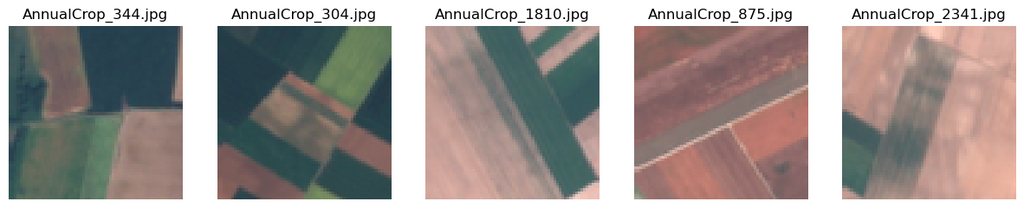

```
Class: Forest
```

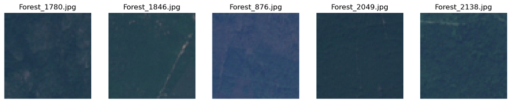

```
Class: HerbaceousVegetation
```

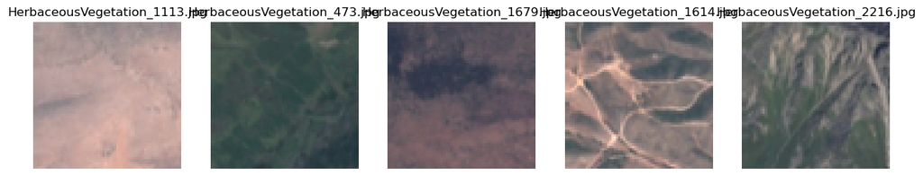

```
Class: Highway
```

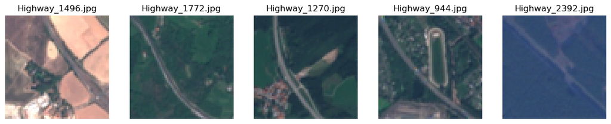

```
Class: Industrial
```

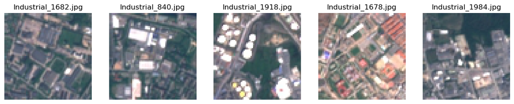

```
Class: Pasture
```

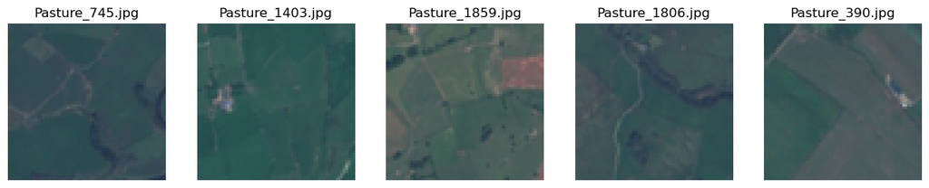

```
Class: PermanentCrop
```

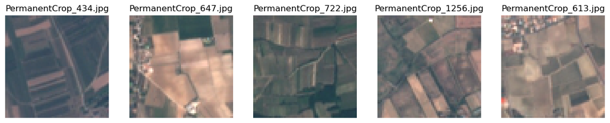

```
Class: Residential
```

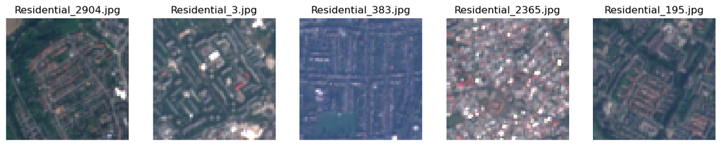

```
Class: River
```

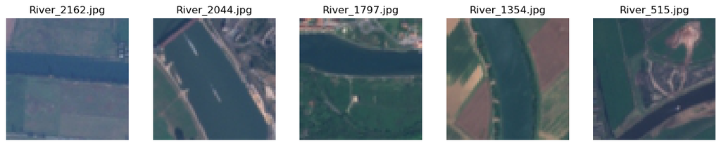

```
Class: SeaLake
```

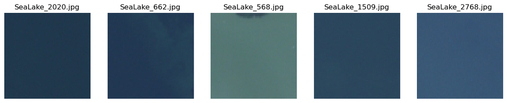

```python
import torch.nn.functional as F
import torch
import torch.nn as nn
import torch.optim as optim
import torchvision
import torchvision.transforms as transforms
import matplotlib.pyplot as plt
import numpy as np
import os
import random
import shutil

# Set device (GPU if available, else CPU)
device = torch.device("cuda" if torch.cuda.is_available() else "cpu")

# Data directory
data_dir = r'C:\Users\varun\OneDrive\Desktop\Assignment\8321\Lab 2\EuroSAT\2750'

# Function to get random images from each class directory
def show_random_images(data_dir, num_samples_per_class=3):
    class_folders = os.listdir(data_dir)
    for class_folder in class_folders:
        class_path = os.path.join(data_dir, class_folder)
        if os.path.isdir(class_path):
            print(f"Class: {class_folder}")
            images = os.listdir(class_path)
            random.shuffle(images)
            sample_images = random.sample(images, min(num_samples_per_class, len(images)))

            fig, axs = plt.subplots(1, num_samples_per_class, figsize=(15, 3))
            for i, image_name in enumerate(sample_images):
                image_path = os.path.join(class_path, image_name)
                image = plt.imread(image_path)
                axs[i].imshow(image)
                axs[i].set_title(image_name)
                axs[i].axis('off')
            plt.show()

# Show random images from each class directory
show_random_images(data_dir, num_samples_per_class=5)
```

### Split the data into training and testing. Be sure to explain how you performed this operation and why you think it is reasonable to split this particular dataset this way.

In the above code I created a test and train subsets from the dataset. I used 80:20 split for this. I used the 80:20 split because the dataset has 27,000 images which when split into train and test gives us

1. Number of samples used for training: 21600
2. Number of samples used for testing: 5400

I believe the number of samples are enough for the models to be effectively trained and tested, with low risk of overfitting or underfitting.

```python
import torch.nn.functional as F
import torch
import torch.nn as nn
import torch.optim as optim
import torchvision
import torchvision.transforms as transforms
import matplotlib.pyplot as plt
import numpy as np
import os
import random
import shutil

# Set device (GPU if available, else CPU)
device = torch.device("cuda" if torch.cuda.is_available() else "cpu")

# Data Loading and Preprocessing
data_dir = r'C:\Users\varun\OneDrive\Desktop\Assignment\8321\Lab 2\EuroSAT\2750'

# Define transforms for data augmentation
data_transforms = {
    'train': transforms.Compose([
        transforms.RandomResizedCrop(224),
        transforms.RandomHorizontalFlip(),
        transforms.ToTensor(),
    ]),
    'test': transforms.Compose([
        transforms.Resize(256),
        transforms.CenterCrop(224),
        transforms.ToTensor(),
    ]),
}

# Function to split data into train and test datasets
def split_data(data_dir, train_dir, test_dir, split_ratio=0.8):
    class_folders = os.listdir(data_dir)
    train_samples = 0
    test_samples = 0
    for class_folder in class_folders:
        class_path = os.path.join(data_dir, class_folder)
        images = os.listdir(class_path)
        random.shuffle(images)
        train_size = int(len(images) * split_ratio)
        train_samples += train_size
        test_samples += len(images) - train_size

        train_images = images[:train_size]
        test_images = images[train_size:]

        # Create train and test directories
        os.makedirs(os.path.join(train_dir, class_folder), exist_ok=True)
        os.makedirs(os.path.join(test_dir, class_folder), exist_ok=True)

        # Move images to train and test directories
        for image in train_images:
            src = os.path.join(class_path, image)
            dst = os.path.join(train_dir, class_folder, image)
            shutil.copyfile(src, dst)
        for image in test_images:
            src = os.path.join(class_path, image)
            dst = os.path.join(test_dir, class_folder, image)
            shutil.copyfile(src, dst)

    print(f"Number of samples used for training: {train_samples}")
    print(f"Number of samples used for testing: {test_samples}")

# Split data into train and test sets
train_data_dir = os.path.join(data_dir, 'train')
test_data_dir = os.path.join(data_dir, 'test')
split_data(data_dir, train_data_dir, test_data_dir)

# Create train and test datasets
train_dataset = torchvision.datasets.ImageFolder(root=train_data_dir, transform=data_transforms['train'])
test_dataset = torchvision.datasets.ImageFolder(root=test_data_dir, transform=data_transforms['test'])

# Create data loaders
batch_size = 32
train_dataloader = torch.utils.data.DataLoader(train_dataset, batch_size=batch_size, shuffle=True, num_workers=4)
test_dataloader = torch.utils.data.DataLoader(test_dataset, batch_size=batch_size, shuffle=False, num_workers=4)

# Get number of classes
num_classes = len(train_dataset.classes)
class_names = train_dataset.classes
```

```
Number of samples used for training: 21600
Number of samples used for testing: 5400
```

```python
import matplotlib.pyplot as plt
import torch
import torchvision

from torch import nn
from torchvision import transforms

device = "cuda" if torch.cuda.is_available() else "cpu"
```

```python
"""
Contains functions for training and testing a PyTorch model.
"""
import torch

from tqdm.auto import tqdm
from typing import Dict, List, Tuple

def train_step(model: torch.nn.Module,
               dataloader: torch.utils.data.DataLoader,
               loss_fn: torch.nn.Module,
               optimizer: torch.optim.Optimizer,
               device: torch.device) -> Tuple[float, float]:

    # Put model in train mode
    model.train()

    # Setup train loss and train accuracy values
    train_loss, train_acc = 0, 0

    # Loop through data loader data batches
    for batch, (X, y) in enumerate(dataloader):
        # Send data to target device
        X, y = X.to(device), y.to(device)

        # 1. Forward pass
        y_pred = model(X)

        # 2. Calculate  and accumulate loss
        loss = loss_fn(y_pred, y)
        train_loss += loss.item()

        # 3. Optimizer zero grad
        optimizer.zero_grad()

        # 4. Loss backward
        loss.backward()

        # 5. Optimizer step
        optimizer.step()

        # Calculate and accumulate accuracy metric across all batches
        y_pred_class = torch.argmax(torch.softmax(y_pred, dim=1), dim=1)
        train_acc += (y_pred_class == y).sum().item()/len(y_pred)

    # Adjust metrics to get average loss and accuracy per batch
    train_loss = train_loss / len(dataloader)
    train_acc = train_acc / len(dataloader)
    return train_loss, train_acc

def test_step(model: torch.nn.Module,
              dataloader: torch.utils.data.DataLoader,
              loss_fn: torch.nn.Module,
              device: torch.device) -> Tuple[float, float]:

    # Put model in eval mode
    model.eval()

    # Setup test loss and test accuracy values
    test_loss, test_acc = 0, 0

    # Turn on inference context manager
    with torch.inference_mode():
        # Loop through DataLoader batches
        for batch, (X, y) in enumerate(dataloader):
            # Send data to target device
            X, y = X.to(device), y.to(device)

            # 1. Forward pass
            test_pred_logits = model(X)

            # 2. Calculate and accumulate loss
            loss = loss_fn(test_pred_logits, y)
            test_loss += loss.item()

            # Calculate and accumulate accuracy
            test_pred_labels = test_pred_logits.argmax(dim=1)
            test_acc += ((test_pred_labels == y).sum().item()/len(test_pred_labels))

    # Adjust metrics to get average loss and accuracy per batch
    test_loss = test_loss / len(dataloader)
    test_acc = test_acc / len(dataloader)
    return test_loss, test_acc


def plot_results(results: Dict[str, List]):
    """Plots the training and testing results."""
    # Get number of epochs
    num_epochs = len(results['train_loss'])

    # Create two subplots for loss and accuracy
    fig, axs = plt.subplots(2, 1, figsize=(10, 10))

    # Plot training and testing loss
    axs[0].plot(range(1, num_epochs+1), results['train_loss'], label='Training Loss', color='blue')
    axs[0].plot(range(1, num_epochs+1), results['test_loss'], label='Testing Loss', color='green')
    axs[0].set_xlabel('Epoch')
    axs[0].set_ylabel('Loss')
    axs[0].set_title('Training and Testing Loss')
    axs[0].grid(True)
    axs[0].legend()

    # Plot training and testing accuracy
    axs[1].plot(range(1, num_epochs+1), results['train_acc'], label='Training Accuracy', color='orange')
    axs[1].plot(range(1, num_epochs+1), results['test_acc'], label='Testing Accuracy', color='red')
    axs[1].set_xlabel('Epoch')
    axs[1].set_ylabel('Accuracy')
    axs[1].set_title('Training and Testing Accuracy')
    axs[1].grid(True)
    axs[1].legend()

    # Adjust layout
    plt.tight_layout()

    # Show the plots
    plt.show()

import time

def train(model: torch.nn.Module,
          train_dataloader: torch.utils.data.DataLoader,
          test_dataloader: torch.utils.data.DataLoader,
          optimizer: torch.optim.Optimizer,
          loss_fn: torch.nn.Module,
          epochs: int,
          device: torch.device) -> Dict[str, List]:

    # Record start time
    start_time = time.time()

    # Create empty results dictionary
    results = {"train_loss": [],
               "train_acc": [],
               "test_loss": [],
               "test_acc": []
    }

    # Make sure model on target device
    model.to(device)

    # Loop through training and testing steps for a number of epochs
    for epoch in tqdm(range(epochs)):
        train_loss, train_acc = train_step(model=model,
                                          dataloader=train_dataloader,
                                          loss_fn=loss_fn,
                                          optimizer=optimizer,
                                          device=device)
        test_loss, test_acc = test_step(model=model,
          dataloader=test_dataloader,
          loss_fn=loss_fn,
          device=device)

        # Print out what's happening
        print(
          f"Epoch: {epoch+1} | "
          f"train_loss: {train_loss:.4f} | "
          f"train_acc: {train_acc:.4f} | "
          f"test_loss: {test_loss:.4f} | "
          f"test_acc: {test_acc:.4f}"
        )

        # Update results dictionary
        results["train_loss"].append(train_loss)
        results["train_acc"].append(train_acc)
        results["test_loss"].append(test_loss)
        results["test_acc"].append(test_acc)

    # Calculate time taken
    end_time = time.time()
    total_time = end_time - start_time
    print(f"Total time taken for training: {total_time:.2f} seconds")

    # Plot the results
    plot_results(results)

    # Return the filled results at the end of the epochs
    return results
```

### Train a model from scratch to perform the classification task (this does NOT need to be a transformer). That is, do not use transfer learning for the classification task. Verify the model converges (even if the model is overfit). This does NOT need to mirror the foundational model. This model may be far less computational to train.

I use a Convolutional Neural Network, the go to choice for image classification tasks. The model consists of two convolutional layers, two fully connected layers and max pooling layer for feature extraction and dimensionality reduction.

```
Epoch: 1 | train_loss: 1.4166 | train_acc: 0.4983 | test_loss: 0.9970 | test_acc: 0.6328
Epoch: 2 | train_loss: 1.0139 | train_acc: 0.6363 | test_loss: 0.8732 | test_acc: 0.6848
Epoch: 3 | train_loss: 0.9042 | train_acc: 0.6788 | test_loss: 0.7795 | test_acc: 0.7367
Epoch: 4 | train_loss: 0.8600 | train_acc: 0.6970 | test_loss: 0.7779 | test_acc: 0.7179
Epoch: 5 | train_loss: 0.8251 | train_acc: 0.7082 | test_loss: 0.7964 | test_acc: 0.7207
Epoch: 6 | train_loss: 0.8058 | train_acc: 0.7134 | test_loss: 0.7078 | test_acc: 0.7528
Epoch: 7 | train_loss: 0.7622 | train_acc: 0.7325 | test_loss: 0.6699 | test_acc: 0.7597
Epoch: 8 | train_loss: 0.7555 | train_acc: 0.7345 | test_loss: 0.6453 | test_acc: 0.7742
Epoch: 9 | train_loss: 0.7329 | train_acc: 0.7422 | test_loss: 0.6013 | test_acc: 0.7870
Epoch: 10 | train_loss: 0.7306 | train_acc: 0.7439 | test_loss: 0.6267 | test_acc: 0.7784
Total time taken for training: 801.13 seconds
```

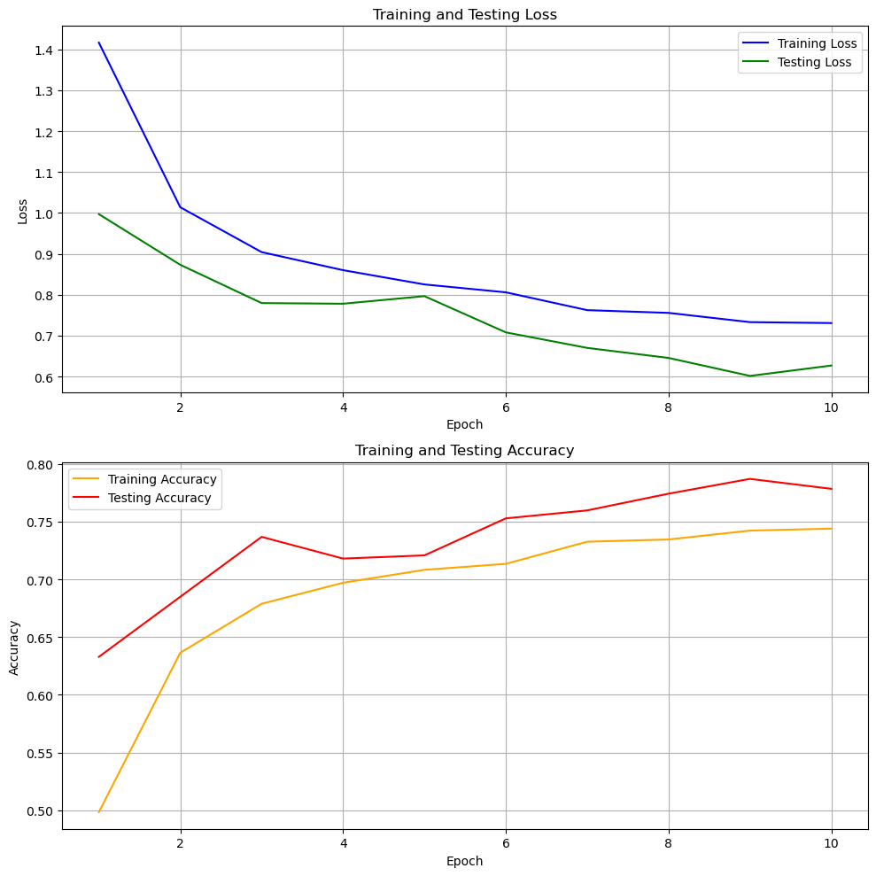

```python
# Define CNN model
class SimpleCNN(nn.Module):
    def __init__(self, num_classes):
        super(SimpleCNN, self).__init__()
        self.conv1 = nn.Conv2d(3, 32, kernel_size=3, padding=1)
        self.conv2 = nn.Conv2d(32, 64, kernel_size=3, padding=1)
        self.pool = nn.MaxPool2d(2, 2)
        self.fc1 = nn.Linear(64 * 56 * 56, 512)
        self.fc2 = nn.Linear(512, num_classes)

    def forward(self, x):
        x = self.pool(torch.relu(self.conv1(x)))
        x = self.pool(torch.relu(self.conv2(x)))
        x = torch.flatten(x, 1)
        x = torch.relu(self.fc1(x))
        x = self.fc2(x)
        return x


# Define the CNN model
simple_cnn = SimpleCNN(num_classes).to(device)

# Define criterion and optimizer for simple CNN model
criterion_cnn = nn.CrossEntropyLoss()
optimizer_cnn = optim.Adam(simple_cnn.parameters(), lr=1e-3)

# Train the CNN model
epochs = 10

results_cnn = train(model=simple_cnn,
                    train_dataloader=train_dataloader,
                    test_dataloader=test_dataloader,
                    optimizer=optimizer_cnn,
                    loss_fn=criterion_cnn,
                    epochs=epochs,
                    device=device)
```

```python
from torchinfo import summary

# Print a summary using torchinfo (uncomment for actual output)
summary(model=pretrained_vit,
        input_size=(32, 3, 224, 224), # (batch_size, color_channels, height, width)
        # col_names=["input_size"], # uncomment for smaller output
        col_names=["input_size", "output_size", "num_params", "trainable"],
        col_width=20,
        row_settings=["var_names"])
```

```
============================================================================================================================================
Layer (type (var_name))                                      Input Shape          Output Shape         Param #              Trainable
============================================================================================================================================
VisionTransformer (VisionTransformer)                        [32, 3, 224, 224]    [32, 10]             768                  Partial
├─Conv2d (conv_proj)                                         [32, 3, 224, 224]    [32, 768, 14, 14]    (590,592)            False
├─Encoder (encoder)                                          [32, 197, 768]       [32, 197, 768]       151,296              False
│    └─Dropout (dropout)                                     [32, 197, 768]       [32, 197, 768]       --                   --
│    └─Sequential (layers)                                   [32, 197, 768]       [32, 197, 768]       --                   False
│    │    └─EncoderBlock (encoder_layer_0)                   [32, 197, 768]       [32, 197, 768]       (7,087,872)          False
│    │    └─EncoderBlock (encoder_layer_1)                   [32, 197, 768]       [32, 197, 768]       (7,087,872)          False
│    │    └─EncoderBlock (encoder_layer_2)                   [32, 197, 768]       [32, 197, 768]       (7,087,872)          False
│    │    └─EncoderBlock (encoder_layer_3)                   [32, 197, 768]       [32, 197, 768]       (7,087,872)          False
│    │    └─EncoderBlock (encoder_layer_4)                   [32, 197, 768]       [32, 197, 768]       (7,087,872)          False
│    │    └─EncoderBlock (encoder_layer_5)                   [32, 197, 768]       [32, 197, 768]       (7,087,872)          False
│    │    └─EncoderBlock (encoder_layer_6)                   [32, 197, 768]       [32, 197, 768]       (7,087,872)          False
│    │    └─EncoderBlock (encoder_layer_7)                   [32, 197, 768]       [32, 197, 768]       (7,087,872)          False
│    │    └─EncoderBlock (encoder_layer_8)                   [32, 197, 768]       [32, 197, 768]       (7,087,872)          False
│    │    └─EncoderBlock (encoder_layer_9)                   [32, 197, 768]       [32, 197, 768]       (7,087,872)          False
│    │    └─EncoderBlock (encoder_layer_10)                  [32, 197, 768]       [32, 197, 768]       (7,087,872)          False
│    │    └─EncoderBlock (encoder_layer_11)                  [32, 197, 768]       [32, 197, 768]       (7,087,872)          False
│    └─LayerNorm (ln)                                        [32, 197, 768]       [32, 197, 768]       (1,536)              False
├─Linear (heads)                                             [32, 768]            [32, 10]             7,690                True
============================================================================================================================================
Total params: 85,806,346
Trainable params: 7,690
Non-trainable params: 85,798,656
Total mult-adds (G): 5.52
============================================================================================================================================
Input size (MB): 19.27
Forward/backward pass size (MB): 3330.74
Params size (MB): 229.22
Estimated Total Size (MB): 3579.23
============================================================================================================================================
```

#### Loading the pretrained model and its weights( which we freeze). After that we remove the final classification layer of the model and replace it with our own classifier which classifies images into 10 classes (the number of classes in our dataset).

```python
# 1. Get pretrained weights for ViT-Base
pretrained_vit_weights = torchvision.models.ViT_B_16_Weights.DEFAULT

# 2. Setup a ViT model instance with pretrained weights
pretrained_vit = torchvision.models.vit_b_16(weights=pretrained_vit_weights).to(device)

# 3. Freeze the base parameters
for parameter in pretrained_vit.parameters():
    parameter.requires_grad = False

loss_fn = torch.nn.CrossEntropyLoss()

pretrained_vit.heads = nn.Linear(in_features=768, out_features=len(class_names)).to(device)
```

### Train a model by transfer learning from your foundational model. Verify that the new model converges. You only need to train a model using the bottleneck features for this step.

I train the below model but all the weights of encoder layers are frozen. No finetuning takes place, except for the final classification layer (heads).

```
Epoch: 1 | train_loss: 0.6532 | train_acc: 0.7927 | test_loss: 0.3606 | test_acc: 0.8856
Epoch: 2 | train_loss: 0.4478 | train_acc: 0.8532 | test_loss: 0.2973 | test_acc: 0.9057
Epoch: 3 | train_loss: 0.4073 | train_acc: 0.8654 | test_loss: 0.2680 | test_acc: 0.9161
Epoch: 4 | train_loss: 0.3750 | train_acc: 0.8760 | test_loss: 0.2547 | test_acc: 0.9177
Epoch: 5 | train_loss: 0.3690 | train_acc: 0.8758 | test_loss: 0.2387 | test_acc: 0.9233
Epoch: 6 | train_loss: 0.3563 | train_acc: 0.8824 | test_loss: 0.2309 | test_acc: 0.9233
Epoch: 7 | train_loss: 0.3373 | train_acc: 0.8870 | test_loss: 0.2335 | test_acc: 0.9247
Epoch: 8 | train_loss: 0.3281 | train_acc: 0.8878 | test_loss: 0.2239 | test_acc: 0.9247
Epoch: 9 | train_loss: 0.3341 | train_acc: 0.8876 | test_loss: 0.2139 | test_acc: 0.9320
Epoch: 10 | train_loss: 0.3233 | train_acc: 0.8917 | test_loss: 0.2081 | test_acc: 0.9314
Total time taken for training: 2995.86 seconds
```

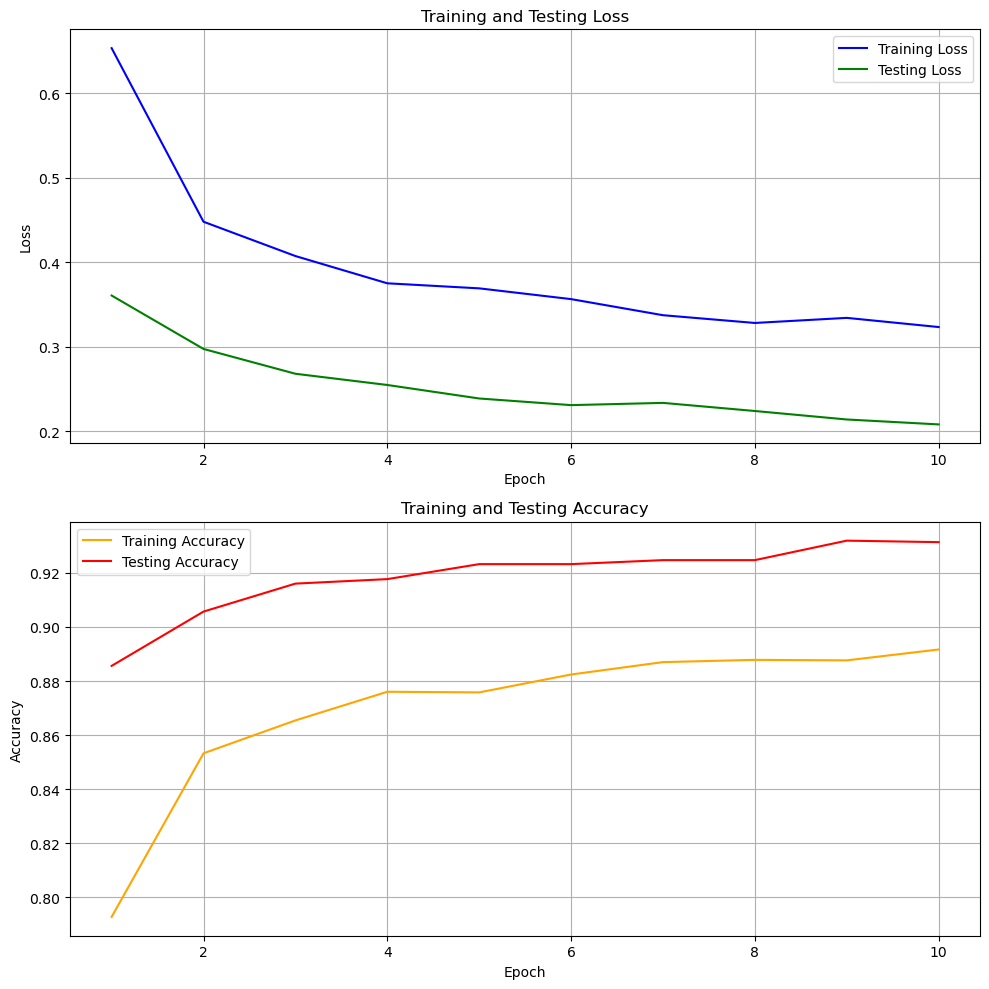

```python
# Create optimizer and loss function
optimizer = torch.optim.Adam(params=pretrained_vit.parameters(),
                             lr=1e-3)
loss_fn = torch.nn.CrossEntropyLoss()

# Train the classifier head of the pretrained ViT feature extractor model

pretrained_vit_results = train(model=pretrained_vit,
                                      train_dataloader=train_dataloader,
                                      test_dataloader=test_dataloader,
                                      optimizer=optimizer,
                                      loss_fn=loss_fn,
                                      epochs=10,
                                      device=device)
```

### Perform fine tuning upon the model by training some layers within the foundational model. Verify that the model converges.

Now I train the layer[11] of the encoder block also, so I unfreeze the weights for it and then finetune them.

#### Model built using finetuning of encoder_layer_11

```
Epoch: 1 | train_loss: 0.4532 | train_acc: 0.8588 | test_loss: 0.2117 | test_acc: 0.9295
Epoch: 2 | train_loss: 0.3402 | train_acc: 0.8854 | test_loss: 0.2084 | test_acc: 0.9356
Epoch: 3 | train_loss: 0.2968 | train_acc: 0.9029 | test_loss: 0.1658 | test_acc: 0.9449
Epoch: 4 | train_loss: 0.3015 | train_acc: 0.9018 | test_loss: 0.1435 | test_acc: 0.9534
Epoch: 5 | train_loss: 0.2868 | train_acc: 0.9054 | test_loss: 0.1652 | test_acc: 0.9502
Epoch: 6 | train_loss: 0.2690 | train_acc: 0.9131 | test_loss: 0.1578 | test_acc: 0.9491
Epoch: 7 | train_loss: 0.2623 | train_acc: 0.9138 | test_loss: 0.1652 | test_acc: 0.9528
Epoch: 8 | train_loss: 0.2523 | train_acc: 0.9184 | test_loss: 0.1331 | test_acc: 0.9549
Epoch: 9 | train_loss: 0.2502 | train_acc: 0.9184 | test_loss: 0.1229 | test_acc: 0.9589
Epoch: 10 | train_loss: 0.2466 | train_acc: 0.9197 | test_loss: 0.1377 | test_acc: 0.9565
Total time taken for training: 3200.69 seconds
```

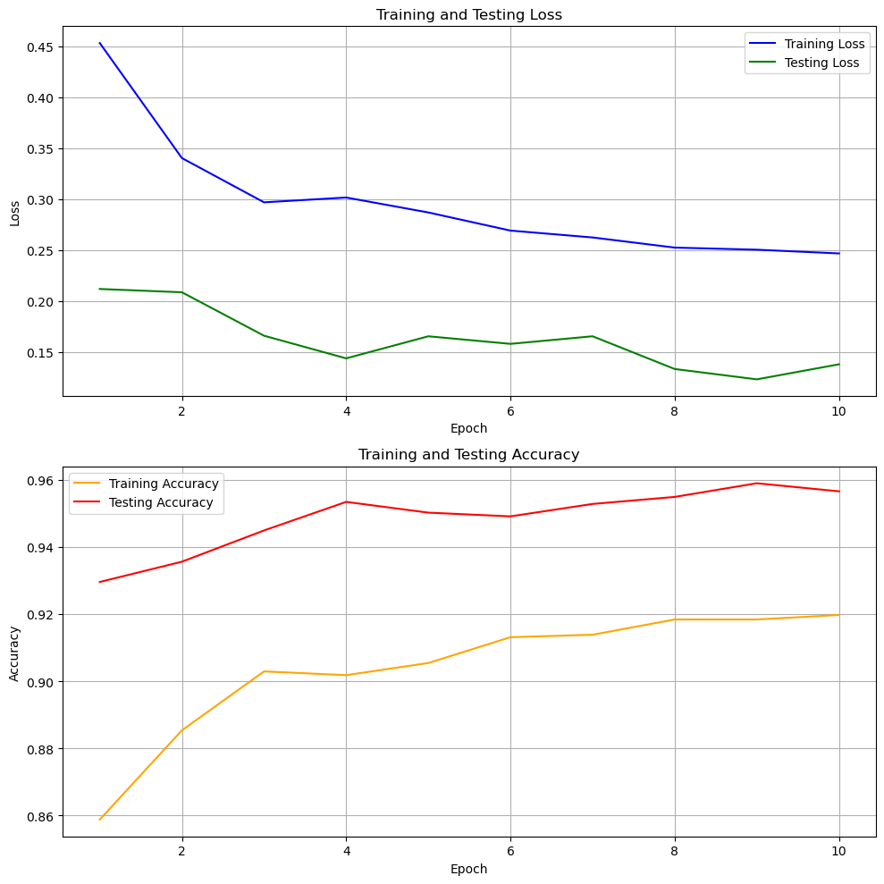

```python
# Identify the layers to fine-tune
layers_to_finetune = [pretrained_vit.encoder.layers[11]]

# Set requires_grad=True for the identified layers
for layer in layers_to_finetune:
    for param in layer.parameters():
        param.requires_grad = True

# Configure optimizer to update parameters of fine-tuned layers
optimizer = torch.optim.Adam(params=pretrained_vit.parameters(),
                             lr=1e-3)

# Train the model with the updated optimizer
pretrained_vit_layer11 = train(model=pretrained_vit,
                               train_dataloader=train_dataloader,
                               test_dataloader=test_dataloader,
                               optimizer=optimizer,
                               loss_fn=loss_fn,
                               epochs=10,
                               device=device)
```

But, I was curious and didn't fully understand the practical differences between finetuning a pre trained model with

1. intial layers of the model
2. final few layers of the model.

In what scenarios it would be beneficial to train initial layers or vice versa.

I knew that if we finetune the initial layers of the model then there is a higher chance of the overfitting of the model, specially if the dataset we have is quite small. When we use the final few layers then we are using what the model has already learned and then customize the final few layers for our own task, which is the essence of transfer learning.

But in my case the dataset that I selected is not small. So I wanted to test how well the model converges in the cases mentioned above. So I went on and built 2 more models,

1. By training initial layers in the EncoderBlock - encoder_layer_0 & encoder_layer_1
2. By training final layers - encoder_layer_10 & encoder_layer_11

#### Model built using finetuning of encoder_layer_0 and encoder_layer_1

```
Epoch: 1 | train_loss: 1.3799 | train_acc: 0.4992 | test_loss: 0.9257 | test_acc: 0.6638
Epoch: 2 | train_loss: 0.8284 | train_acc: 0.7085 | test_loss: 0.6417 | test_acc: 0.7783
Epoch: 3 | train_loss: 0.7142 | train_acc: 0.7506 | test_loss: 0.6259 | test_acc: 0.7748
Epoch: 4 | train_loss: 0.6285 | train_acc: 0.7839 | test_loss: 0.5633 | test_acc: 0.8067
Epoch: 5 | train_loss: 0.5823 | train_acc: 0.7986 | test_loss: 0.5100 | test_acc: 0.8208
Epoch: 6 | train_loss: 0.5449 | train_acc: 0.8150 | test_loss: 0.4957 | test_acc: 0.8347
Epoch: 7 | train_loss: 0.5124 | train_acc: 0.8234 | test_loss: 0.4428 | test_acc: 0.8484
Epoch: 8 | train_loss: 0.4848 | train_acc: 0.8334 | test_loss: 0.4040 | test_acc: 0.8600
Epoch: 9 | train_loss: 0.4604 | train_acc: 0.8426 | test_loss: 0.4939 | test_acc: 0.8375
Epoch: 10 | train_loss: 0.4322 | train_acc: 0.8506 | test_loss: 0.3595 | test_acc: 0.8799
Total time taken for training: 5719.62 seconds
```

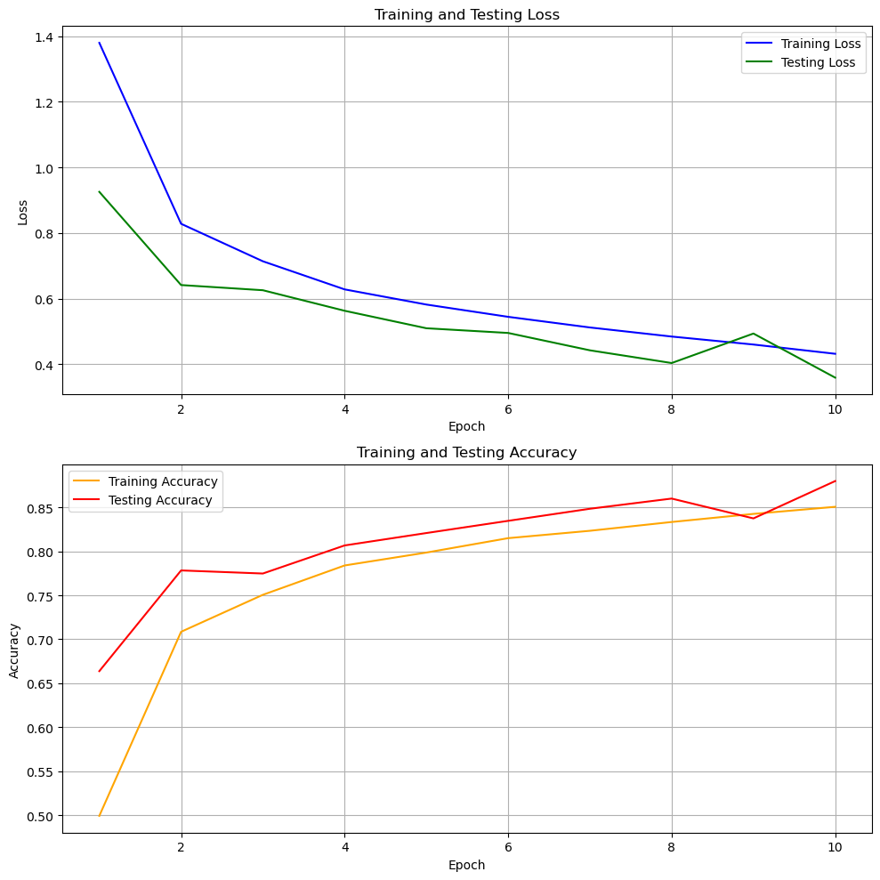

```python
# Identify the layers to fine-tune
layers_to_finetune = [pretrained_vit.encoder.layers[0], pretrained_vit.encoder.layers[1]]

# Set requires_grad=True for the identified layers
for layer in layers_to_finetune:
    for param in layer.parameters():
        param.requires_grad = True

# Configure optimizer to update parameters of fine-tuned layers
optimizer = torch.optim.Adam(params=pretrained_vit.parameters(),
                             lr=1e-3)

# Train the model with the updated optimizer
pretrained_vit_layers_0_1 = train(model=pretrained_vit,
                               train_dataloader=train_dataloader,
                               test_dataloader=test_dataloader,
                               optimizer=optimizer,
                               loss_fn=loss_fn,
                               epochs=10,
                               device=device)
```

#### Model built using finetuning of encoder_layer_10 and encoder_layer_11

```
Epoch: 1 | train_loss: 0.3512 | train_acc: 0.8933 | test_loss: 0.1502 | test_acc: 0.9485
Epoch: 2 | train_loss: 0.2526 | train_acc: 0.9151 | test_loss: 0.1384 | test_acc: 0.9536
Epoch: 3 | train_loss: 0.2327 | train_acc: 0.9235 | test_loss: 0.1657 | test_acc: 0.9477
Epoch: 4 | train_loss: 0.2210 | train_acc: 0.9268 | test_loss: 0.1214 | test_acc: 0.9615
Epoch: 5 | train_loss: 0.2197 | train_acc: 0.9284 | test_loss: 0.1534 | test_acc: 0.9539
Epoch: 6 | train_loss: 0.2082 | train_acc: 0.9306 | test_loss: 0.1533 | test_acc: 0.9534
Epoch: 7 | train_loss: 0.2158 | train_acc: 0.9298 | test_loss: 0.1242 | test_acc: 0.9593
Epoch: 8 | train_loss: 0.2054 | train_acc: 0.9316 | test_loss: 0.1222 | test_acc: 0.9621
Epoch: 9 | train_loss: 0.2014 | train_acc: 0.9352 | test_loss: 0.1106 | test_acc: 0.9639
Epoch: 10 | train_loss: 0.1988 | train_acc: 0.9371 | test_loss: 0.1182 | test_acc: 0.9650
Total time taken for training: 3414.62 seconds
```

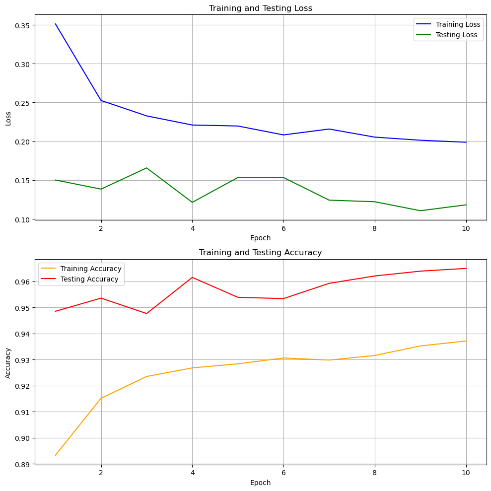

```python
# Identify the layers to fine-tune
layers_to_finetune = [pretrained_vit.encoder.layers[10], pretrained_vit.encoder.layers[11]]

# Set requires_grad=True for the identified layers
for layer in layers_to_finetune:
    for param in layer.parameters():
        param.requires_grad = True

# Configure optimizer to update parameters of fine-tuned layers
optimizer = torch.optim.Adam(params=pretrained_vit.parameters(),
                             lr=1e-3)

# Train the model with the updated optimizer
pretrained_vit_layers_10_11 = train(model=pretrained_vit,
                               train_dataloader=train_dataloader,
                               test_dataloader=test_dataloader,
                               optimizer=optimizer,
                               loss_fn=loss_fn,
                               epochs=10,
                               device=device)
```

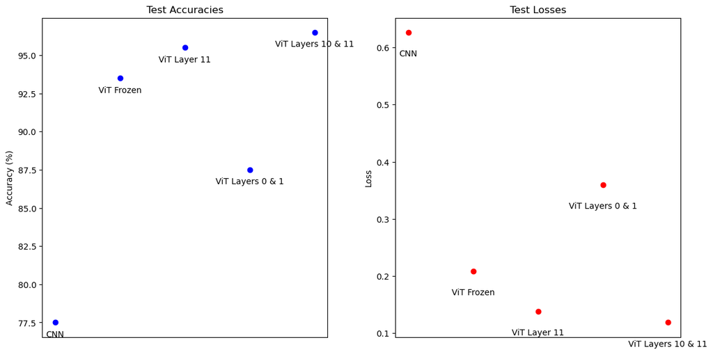

```python
import matplotlib.pyplot as plt

# Model descriptions
models = [
    "CNN",
    "ViT Frozen",
    "ViT Layer 11",
    "ViT Layers 0 & 1",
    "ViT Layers 10 & 11"
]

# Test accuracies and test losses
test_accuracies = [77.5, 93.5, 95.5, 87.5, 96.5]  # Test accuracies in percentage
test_losses = [0.6267, 0.2081, 0.1377, 0.3595, 0.1182]

# Create subplots
fig, axs = plt.subplots(1, 2, figsize=(12, 6))

# Plot test accuracies as points with lines connecting them
for i, model in enumerate(models):
    axs[0].plot(i, test_accuracies[i], marker='o', linestyle='', color='blue')
    axs[0].text(i, test_accuracies[i] - .5, model, ha='center', va='top', rotation=0)

axs[0].set_title('Test Accuracies')
axs[0].set_ylabel('Accuracy (%)')
axs[0].set_xticks([])  # Remove x-axis ticks

# Plot test losses as points with lines connecting them
for i, model in enumerate(models):
    axs[1].plot(i, test_losses[i], marker='o', linestyle='', color='red')
    axs[1].text(i, test_losses[i] - 0.03, model, ha='center', va='top', rotation=0)

axs[1].set_title('Test Losses')
axs[1].set_ylabel('Loss')
axs[1].set_xticks([])  # Remove x-axis ticks

# Adjust layout
plt.tight_layout()

# Show the plot
plt.show()
```

### Report the results of all models using the evaluation procedure that you argued for at the beginning of the lab. Compare the convergence of the models and the running time. Results should be reported with proper statistical comparisons and proper visualizations.

Below table shows the train and test accuracy and losses for the 5 models that we created. CNN was our model which is often used for image classification tasks. The below values are approximate values of parameters after the models were trained for 10 epochs. I have also used a visualization to compare the Test Accuracies and Testing Loss.

| Model Description | Train Accuracy | Test Accuracy | Training Loss | Testing Loss | Running Time |
| --- | --- | --- | --- | --- | --- |
| 1. CNN - our basic classifier model | 74-75 % | 77-78 % | 0.7306 | 0.6267 | 13 mins 21 seconds |
| 2. ViT, all layers frozen | 89-90 % | 93-94 % | 0.3233 | 0.2081 | 49 mins 56 seconds |
| 3. ViT, finetuned encoder layer 11 | 91-92 % | 95-96 % | 0.2466 | 0.1377 | 53 mins 20 seconds |
| 4. ViT, finetuned encoder layers 0 & 1 | 85-86 % | 87-88 % | 0.4322 | 0.3595 | 95 mins 19 seconds |
| 5. ViT, finetuned encoder layer 10 & 11 | 93-94 % | 96-97 % | 0.1988 | 0.1182 | 56 mins 54 seconds |

I wanted to test was the comparison between models where initial layers were finetuned vs the model where the final layers were finetuned. When we compare these two we see a significantly longer training time for the model where the first two layers were finetuned. The model took 95 minutes (approximately) to train, which is the most out of all the models. The model where we finetuned layers 10 and 11, only took 57 minutes (approximately). This training time is only 3 minutes more than the model where we finetuned only layer 11.

From the test accuracies column, we see the most accurate model was also the transfer learning model in which we changed the classifier and finetuned layers 10 and 11.

Our own CNN model converged well, with reducing loss in every epoch that we trained, it only took a fourth of the time compared to the most accurate models. I believe if we had trained this model for more epochs then we could have achieved better accuracy. The test accuracy of 77-78% that we obtained is not great but I believe we can improve it.

One more thing that I believe can improve the performance of all the models is by using a higher number of epochs, but again we will have to compromise on the time taken to train those models.

### References

https://medium.com/@yanis.labrak/how-to-train-a-custom-vision-transformer-vit-image-classifier-to-help-endoscopists-in-under-5-min-2e7e4110a353  
https://huggingface.co/blog/fine-tune-vit  
https://pytorch.org/tutorials/beginner/transfer_learning_tutorial.html  
https://www.youtube.com/watch?v=1ytfli6sGt4&list=PLv8Cp2NvcY8CaSVfCIyg5mvek8JvaD7tE&index=110  
https://github.com/AarohiSingla/Image-Classification-Using-Vision-transformer/blob/main/train_using_pretrained_model_image_classifier.ipynb  
https://github.com/phelber/eurosat?tab=readme-ov-file  
https://sentinels.copernicus.eu/web/sentinel/missions/sentinel-2  
https://en.wikipedia.org/wiki/Sentinel-2  
https://www.image-net.org/about.php  
https://en.wikipedia.org/wiki/Copernicus_Programme

I also used chat-gpt to generate and debug code.

### Dataset

[1] P. Helber, B. Bischke, A. Dengel, and D. Borth, "Eurosat: A novel dataset and deep learning benchmark for land use and land cover classification," IEEE Journal of Selected Topics in Applied Earth Observations and Remote Sensing, 2019.  
[2] Introducing EuroSAT: A Novel Dataset and Deep Learning Benchmark for Land Use and Land Cover Classification. Patrick Helber, Benjamin Bischke, Andreas Dengel. 2018 IEEE International Geoscience and Remote Sensing Symposium, 2018.